# Exploratoary results - Predator Richness and Genotypic variation Interactively Shape Prey Evolution

Author

Ze-Yi Han

Published

October 23, 2026

# Population dynamics analysis

## Overall population dynamics

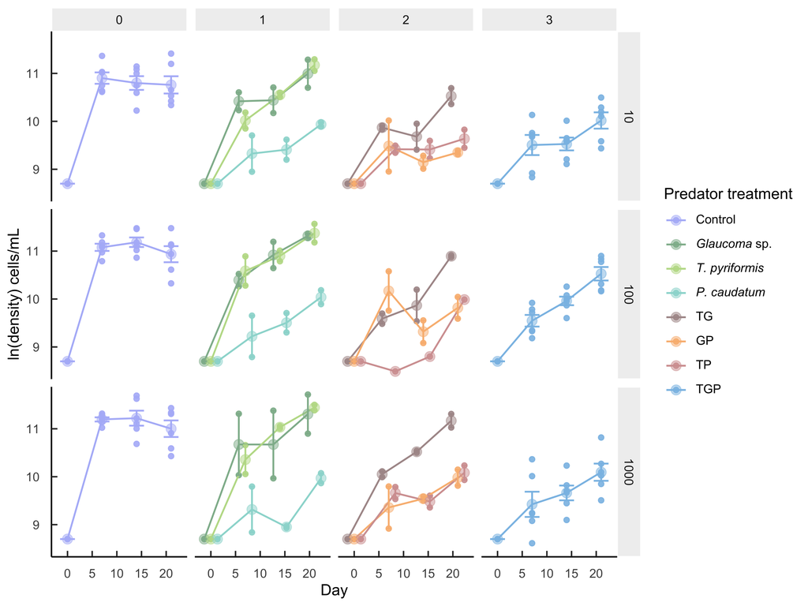

Figure 1: Population density over time across predator richness and genetic variaation treatments.

```r
tar_read(fig_pop_dynamics)
```

### Population dynamics models

Hypothesis testing:

- Do predator richness and genotypic variation interactively affect prey population dynamics?
- Do predator presence interactively or additively affect prey population dynamics?

#### 1. Check for temporal autocorrelation

```r
knitr::kable(tar_read(mod_dyn_autocorr_check)$aic, digits = 2)
```

Table 1: AIC comparison of autoregressive error structures (full model, REML).

|  | model | AIC | dAIC |
| --- | --- | --- | --- |
| AR0 | AR0 | 284.82 | 3.03 |
| AR1 | AR1 | 281.79 | 0.00 |
| AR2 | AR2 | 283.79 | 2.00 |

Tested: none, AR(1), AR(2). AR(1) was best supported (ΔAIC ≥ 2 relative to alternatives) and was used for inference.

#### 2. PR GV interactive effects?

```r
knitr::kable(tar_read(anova_pr_gv))
```

Table 2: Anova table for model testing predator richness and genotypic variation interactive effects.

|  | Chisq | Df | Pr(>Chisq) |
| --- | --- | --- | --- |
| PredNum_f | 3.905142 | 3 | 0.2718909 |
| GV_f | 7.900877 | 2 | 0.0192463 |
| Day_f | 95.522409 | 2 | 0.0000000 |
| PredNum_f:GV_f | 4.414243 | 6 | 0.6208049 |
| PredNum_f:Day_f | 69.875337 | 6 | 0.0000000 |
| GV_f:Day_f | 4.526351 | 4 | 0.3394344 |
| PredNum_f:GV_f:Day_f | 10.723880 | 12 | 0.5527187 |

GV main effects significant, day and day*pred richness significant. Both PR and GV significantly affect prey population dynamics. But no GV and PR interactive effects.

#### 3. Predator presence interactive or additive?

```r
knitr::kable(tar_read(anova_pred_int))
```

Table 3: Anova table for model testing predator richness and genotypic variation interactive effects on over all C. reinhardtii population dynamics.

|  | Chisq | Df | Pr(>Chisq) |
| --- | --- | --- | --- |
| GV_f | 8.0111194 | 2 | 0.0182141 |
| Day_f | 125.3999247 | 2 | 0.0000000 |
| Tetra | 1.5919579 | 1 | 0.2070466 |
| Glauc | 1.4179022 | 1 | 0.2337490 |
| Pcaud | 170.5087621 | 1 | 0.0000000 |
| GV_f:Day_f | 5.9058786 | 4 | 0.2062884 |
| GV_f:Tetra | 0.5946355 | 2 | 0.7428079 |
| Day_f:Tetra | 38.5430645 | 2 | 0.0000000 |
| GV_f:Glauc | 0.7865318 | 2 | 0.6748493 |
| Day_f:Glauc | 4.9692663 | 2 | 0.0833561 |
| Tetra:Glauc | 0.1315906 | 1 | 0.7167885 |
| GV_f:Pcaud | 2.3773523 | 2 | 0.3046243 |
| Day_f:Pcaud | 5.3116616 | 2 | 0.0702405 |
| Tetra:Pcaud | 7.5567520 | 1 | 0.0059786 |
| Glauc:Pcaud | 10.4076567 | 1 | 0.0012549 |
| GV_f:Day_f:Tetra | 3.9443844 | 4 | 0.4135849 |
| GV_f:Day_f:Glauc | 3.0812484 | 4 | 0.5443219 |
| GV_f:Tetra:Glauc | 0.2862835 | 2 | 0.8666312 |
| Day_f:Tetra:Glauc | 0.4325424 | 2 | 0.8055168 |
| GV_f:Day_f:Pcaud | 3.8920722 | 4 | 0.4208093 |
| GV_f:Tetra:Pcaud | 0.2777832 | 2 | 0.8703223 |
| Day_f:Tetra:Pcaud | 6.5884029 | 2 | 0.0370977 |
| GV_f:Glauc:Pcaud | 3.1782040 | 2 | 0.2041088 |
| Day_f:Glauc:Pcaud | 19.1235251 | 2 | 0.0000704 |
| Tetra:Glauc:Pcaud | 3.5367427 | 1 | 0.0600232 |
| GV_f:Day_f:Tetra:Glauc | 1.9651386 | 4 | 0.7421710 |
| GV_f:Day_f:Tetra:Pcaud | 8.4830300 | 4 | 0.0754033 |
| GV_f:Day_f:Glauc:Pcaud | 11.9347618 | 4 | 0.0178430 |
| GV_f:Tetra:Glauc:Pcaud | 2.9301352 | 2 | 0.2310624 |
| Day_f:Tetra:Glauc:Pcaud | 14.1637034 | 2 | 0.0008402 |
| GV_f:Day_f:Tetra:Glauc:Pcaud | 5.9461307 | 4 | 0.2032076 |

TP, GP, TGP have significant interaction, but not TG - fair. TG are similar and both weaker predators. GV main effect significant, but its effect likely is different depending on predator composition.

### PR GV effects on population variations

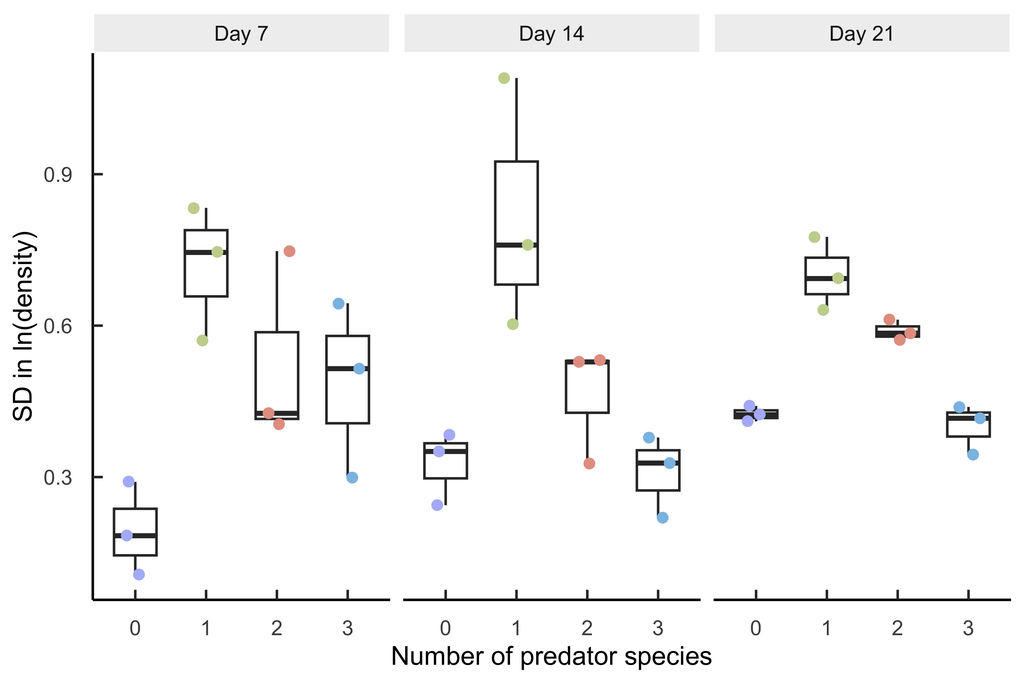

Figure 2: Variation across replicates within predator richness treatments overtime.

```r
tar_read(fig_sd_richness)
```

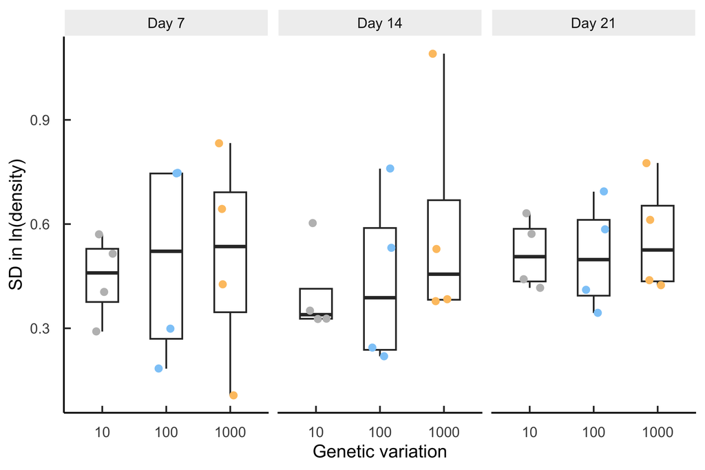

Figure 3: Variation across replicates within genotypic variation treatments overtime.

```r
tar_read(fig_sd_gv)
```

hard to tell GV effect just by looking at the plot

generalized linear model to test GV and PR effects on population variation. hypothese - high GV decrease variability, PR here would decrease variation.

```r
knitr::kable(tar_read(anova_sd))
```

Table 4: Anova table for model testing predator richness and genotypic variation interactive effects on variations in population dynamcis.

|  | LR Chisq | Df | Pr(>Chisq) |
| --- | --- | --- | --- |
| GV_f | 1.541642 | 2 | 0.4626332 |
| Day_f | 2.518349 | 2 | 0.2838882 |
| PredNum_f | 48.268152 | 3 | 0.0000000 |
| GV_f:Day_f | 2.411421 | 4 | 0.6605642 |
| Day_f:PredNum_f | 14.882881 | 6 | 0.0211875 |

Predator richness affects but genotypic variation doesn’t affect variation across populations.

# Evolutionary outcome analysis

## Vistuatlizing delta change in genotypic frequency

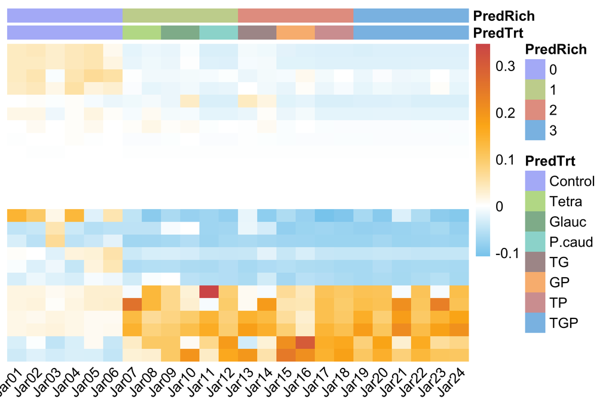

Figure 4: Delta freq change in GV10.

```r
print(tar_read(hmp_dlt_gv10))
```

Clear control vs predation different –> competition vs predation defenese trade-off

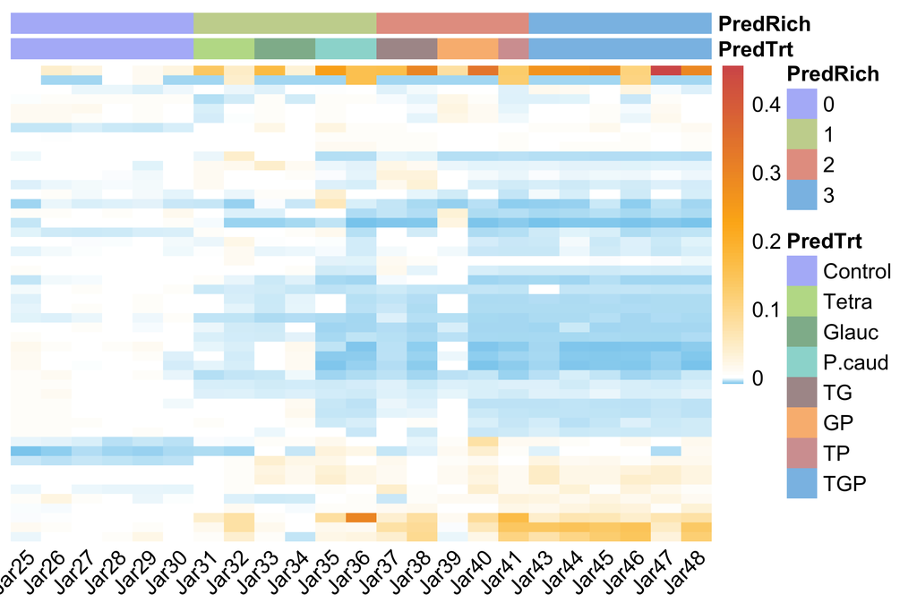

Figure 5: Delta freq change in GV100.

```r
print(tar_read(hmp_dlt_gv100))
```

One super performer strain that has increasing frequency with increasing predator richness. It do better under stronger predation selection.

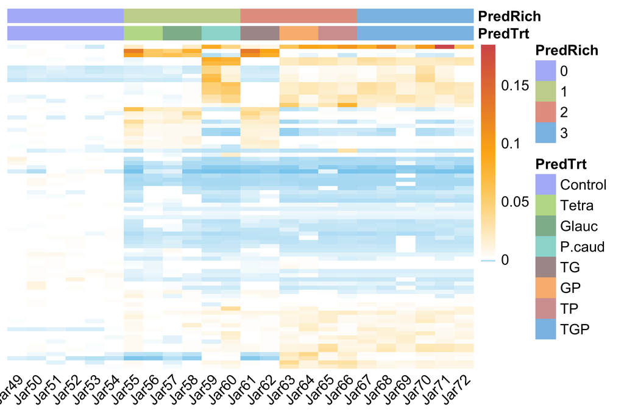

Figure 6: Delta freq change in GV1000.

```r
print(tar_read(hmp_dlt_gv1000))
```

Clear different selection pattern from small vs large ciliates.

## Quantifying genotypic loss and diversity

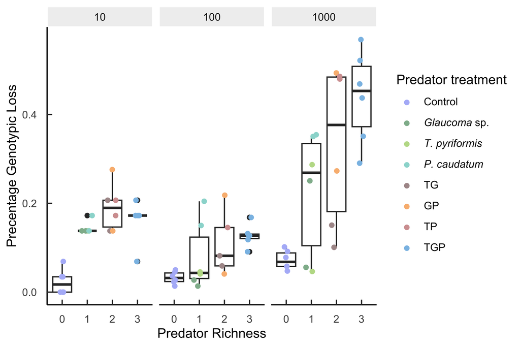

Figure 7: Percentage genotypic loss in prey population.

```r
tar_read(fig_bc_perc_loss)
```

```r
knitr::kable(tar_read(anova_bc_loss))
#knitr::kable(broom::tidy(tar_read(fit_mod_bc_loss)))     # coefficients, SE, t, p
#knitr::kable(broom::glance(tar_read(fit_mod_bc_loss)))
```

|  | Sum Sq | Df | F value | Pr(>F) |
| --- | --- | --- | --- | --- |
| PredNum_f | 670189 | 3 | 9.797932 | 2.44e-05 |
| GV_f | 31602636 | 2 | 693.029535 | 0.00e+00 |
| PredNum_f:GV_f | 1208392 | 6 | 8.833138 | 7.00e-07 |
| Residuals | 1345221 | 59 | NA | NA |

```r
knitr::kable(broom::tidy(tar_read(mod_bc_perc_loss)))
```

| term | estimate | std.error | statistic | p.value |
| --- | --- | --- | --- | --- |
| (Intercept) | 28.333333 | 61.64462 | 0.4596238 | 0.6474755 |
| PredNum_f1 | -3.500000 | 87.17865 | -0.0401474 | 0.9681111 |
| PredNum_f2 | -4.833333 | 87.17865 | -0.0554417 | 0.9559739 |
| PredNum_f3 | -4.000000 | 87.17865 | -0.0458828 | 0.9635586 |
| GV_f100 | 184.500000 | 87.17865 | 2.1163438 | 0.0385443 |
| GV_f1000 | 1885.166667 | 87.17865 | 21.6241773 | 0.0000000 |
| PredNum_f1:GV_f100 | -7.000000 | 123.28923 | -0.0567771 | 0.9549146 |
| PredNum_f2:GV_f100 | -12.000000 | 126.33387 | -0.0949864 | 0.9246475 |
| PredNum_f3:GV_f100 | -16.833333 | 123.28923 | -0.1365353 | 0.8918629 |
| PredNum_f1:GV_f1000 | -309.333333 | 123.28923 | -2.5090052 | 0.0148738 |
| PredNum_f2:GV_f1000 | -527.666667 | 123.28923 | -4.2799087 | 0.0000696 |
| PredNum_f3:GV_f1000 | -753.333333 | 123.28923 | -6.1102929 | 0.0000001 |

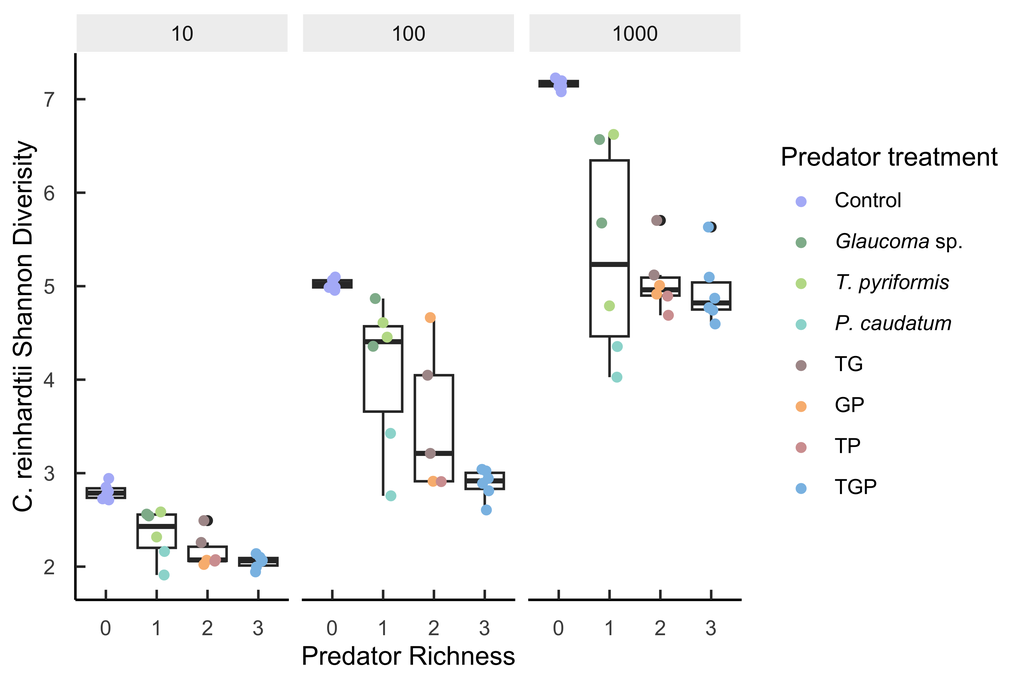

```r
tar_read(fig_bc_shannon)
```

```r
knitr::kable(tar_read(anova_bc_shann))
```

Table 6: Anova table for model testing predator richness and genotypic variation interactive effects on genotypic Shannon diverity of prey population.

[output not shown]